# Tarea-California

Ignacio Vellido

11/11/2020

## Descripción del dataset

This data set contains information about all the block groups in California from the 1990 Census. In this sample a block group on average includes 1425.5 individuals living in a geographically compact area.

The task is to aproximate the median house value of each block from the values of the rest of the variables.

Contiene las siguientes variables:

- Longitude: real[-124.35,-114.31]
- Latitude: real[32.54,41.95]
- HousingMedianAge: real[1,52]
- TotalRooms: real[2,39320]
- TotalBedrooms: real[1,6445]
- Population: real[3,35682]
- Households: real[1,6082]
- MedianIncome: real[0.4999,15.0001]
- Output - **MedianHouseValue**: real[14999,500001]

Cargamos los datos

```r
xtra <- read.csv("./data/california.dat", comment.char="@", header = FALSE)

# Asignamos nombres automáticamente para facilitar el acceso
n <- length(names(xtra)) - 1
names(xtra)[1:n] <- paste("X", 1:n, sep="")
names(xtra)[n+1] <- "Y"

attach(xtra)
head(xtra)
```

|  | X1 | X2 | X3 | X4 | X5 | X6 | X7 | X8 | Y |
| --- | --- | --- | --- | --- | --- | --- | --- | --- | --- |
| 1 | -117.03 | 32.78 | 17 | 5481 | 1618 | 2957 | 1537 | 2.5707 | 171300 |
| 2 | -118.23 | 33.80 | 26 | 239 | 135 | 165 | 112 | 1.3333 | 187500 |
| 3 | -122.46 | 37.71 | 39 | 2076 | 482 | 1738 | 445 | 3.1958 | 232100 |
| 4 | -122.06 | 37.94 | 19 | 4005 | 972 | 1896 | 893 | 2.5268 | 235700 |
| 5 | -122.87 | 38.68 | 32 | 4073 | 718 | 2053 | 629 | 3.7352 | 228000 |
| 6 | -122.47 | 37.66 | 18 | 4172 | 806 | 3226 | 790 | 5.7535 | 297900 |

Previsualicación de las variables respecto a la salida

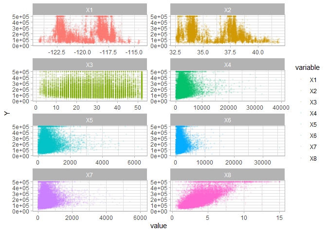

```r
# Usando ggplot
aux <- melt(xtra, "Y")

ggplot(aux, aes(x=value, y=Y, color=variable)) +
  geom_point(alpha=0.1, pch=20) +
  facet_wrap(.~variable, scale="free", ncol = 2) +
  theme_light()
```

No se ve linealidad aparente entre las variables y la salida.

X8 podría seguir una logarítmica.

Ampliamos el gráfico para ella:

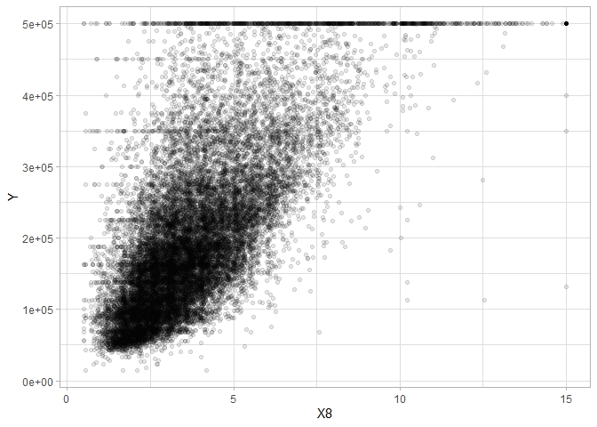

```r
ggplot(xtra, aes(x=X8, y=Y)) +
  geom_point(alpha=0.1) +
  theme_light()
```

Podría haber sido lineal pero la nube de puntos de arriba no da buenas sensaciones.

## Modelos univariables

Obtenemos un modelo simple para cada variable

```r
fit1 <- lm(Y~X1, data=xtra)
fit2 <- lm(Y~X2, data=xtra)
fit3 <- lm(Y~X3, data=xtra)
fit4 <- lm(Y~X4, data=xtra)
fit5 <- lm(Y~X5, data=xtra)
fit6 <- lm(Y~X6, data=xtra)
fit7 <- lm(Y~X7, data=xtra)
fit8 <- lm(Y~X8, data=xtra)
```

Visualizamos cada fit

```r
summary(fit1)
```

```
Call:
lm(formula = Y ~ X1, data = xtra)

Residuals:
    Min      1Q  Median      3Q     Max
-201389  -86462  -26343   56597  301458

Coefficients:
             Estimate Std. Error t value Pr(>|t|)
(Intercept) -109704.7    47894.1  -2.291    0.022 *
X1            -2647.5      400.5  -6.611 3.92e-11 ***
---
Signif. codes:  0 '***' 0.001 '**' 0.01 '*' 0.05 '.' 0.1 ' ' 1

Residual standard error: 115300 on 20638 degrees of freedom
Multiple R-squared:  0.002113,  Adjusted R-squared:  0.002065
F-statistic:  43.7 on 1 and 20638 DF,  p-value: 3.923e-11
```

```r
summary(fit2)
```

```
Call:
lm(formula = Y ~ X2, data = xtra)

Residuals:
    Min      1Q  Median      3Q     Max
-207112  -84020  -30051   57108  318676

Coefficients:
            Estimate Std. Error t value Pr(>|t|)
(Intercept) 484367.9    13283.8   36.46   <2e-16 ***
X2           -7788.3      372.1  -20.93   <2e-16 ***
---
Signif. codes:  0 '***' 0.001 '**' 0.01 '*' 0.05 '.' 0.1 ' ' 1

Residual standard error: 114200 on 20638 degrees of freedom
Multiple R-squared:  0.02078,   Adjusted R-squared:  0.02073
F-statistic:   438 on 1 and 20638 DF,  p-value: < 2.2e-16
```

```r
summary(fit3)
```

```
Call:
lm(formula = Y ~ X3, data = xtra)

Residuals:
    Min      1Q  Median      3Q     Max
-214480  -85038  -25815   58338  318944

Coefficients:
             Estimate Std. Error t value Pr(>|t|)
(Intercept) 179119.92    1985.42   90.22   <2e-16 ***
X3             968.45      63.47   15.26   <2e-16 ***
---
Signif. codes:  0 '***' 0.001 '**' 0.01 '*' 0.05 '.' 0.1 ' ' 1

Residual standard error: 114800 on 20638 degrees of freedom
Multiple R-squared:  0.01116,   Adjusted R-squared:  0.01111
F-statistic: 232.8 on 1 and 20638 DF,  p-value: < 2.2e-16
```

```r
summary(fit4)
```

```
Call:
lm(formula = Y ~ X4, data = xtra)

Residuals:
    Min      1Q  Median      3Q     Max
-313466  -86435  -26710   55724  311792

Coefficients:
             Estimate Std. Error t value Pr(>|t|)
(Intercept) 1.882e+05  1.248e+03  150.72   <2e-16 ***
X4          7.096e+00  3.649e-01   19.45   <2e-16 ***
---
Signif. codes:  0 '***' 0.001 '**' 0.01 '*' 0.05 '.' 0.1 ' ' 1

Residual standard error: 114400 on 20638 degrees of freedom
Multiple R-squared:  0.018, Adjusted R-squared:  0.01795
F-statistic: 378.2 on 1 and 20638 DF,  p-value: < 2.2e-16
```

```r
summary(fit5)
```

```
Call:
lm(formula = Y ~ X5, data = xtra)

Residuals:
    Min      1Q  Median      3Q     Max
-214259  -87387  -27790   57324  300586

Coefficients:
             Estimate Std. Error t value Pr(>|t|)
(Intercept) 1.994e+05  1.301e+03 153.254  < 2e-16 ***
X5          1.386e+01  1.904e+00   7.278 3.52e-13 ***
---
Signif. codes:  0 '***' 0.001 '**' 0.01 '*' 0.05 '.' 0.1 ' ' 1

Residual standard error: 115300 on 20638 degrees of freedom
Multiple R-squared:  0.00256,   Adjusted R-squared:  0.002511
F-statistic: 52.96 on 1 and 20638 DF,  p-value: 3.52e-13
```

```r
summary(fit6)
```

```
Call:
lm(formula = Y ~ X6, data = xtra)

Residuals:
    Min      1Q  Median      3Q     Max
-195392  -86885  -26889   58179  308230

Coefficients:
              Estimate Std. Error t value Pr(>|t|)
(Intercept)  2.104e+05  1.291e+03 163.012  < 2e-16 ***
X6          -2.512e+00  7.091e-01  -3.542 0.000398 ***
---
Signif. codes:  0 '***' 0.001 '**' 0.01 '*' 0.05 '.' 0.1 ' ' 1

Residual standard error: 115400 on 20638 degrees of freedom
Multiple R-squared:  0.0006076, Adjusted R-squared:  0.0005592
F-statistic: 12.55 on 1 and 20638 DF,  p-value: 0.0003976
```

```r
summary(fit7)
```

```
Call:
lm(formula = Y ~ X7, data = xtra)

Residuals:
    Min      1Q  Median      3Q     Max
-224789  -86852  -27950   56970  303053

Coefficients:
             Estimate Std. Error t value Pr(>|t|)
(Intercept) 1.969e+05  1.319e+03 149.330   <2e-16 ***
X7          1.987e+01  2.096e+00   9.479   <2e-16 ***
---
Signif. codes:  0 '***' 0.001 '**' 0.01 '*' 0.05 '.' 0.1 ' ' 1

Residual standard error: 115100 on 20638 degrees of freedom
Multiple R-squared:  0.004335,  Adjusted R-squared:  0.004287
F-statistic: 89.86 on 1 and 20638 DF,  p-value: < 2.2e-16
```

```r
summary(fit8)
```

```
Call:
lm(formula = Y ~ X8, data = xtra)

Residuals:
    Min      1Q  Median      3Q     Max
-540697  -55950  -16979   36978  434023

Coefficients:
            Estimate Std. Error t value Pr(>|t|)
(Intercept)  45085.6     1322.9   34.08   <2e-16 ***
X8           41793.8      306.8  136.22   <2e-16 ***
---
Signif. codes:  0 '***' 0.001 '**' 0.01 '*' 0.05 '.' 0.1 ' ' 1

Residual standard error: 83740 on 20638 degrees of freedom
Multiple R-squared:  0.4734,    Adjusted R-squared:  0.4734
F-statistic: 1.856e+04 on 1 and 20638 DF,  p-value: < 2.2e-16
```

Mostramos el ajuste para X8

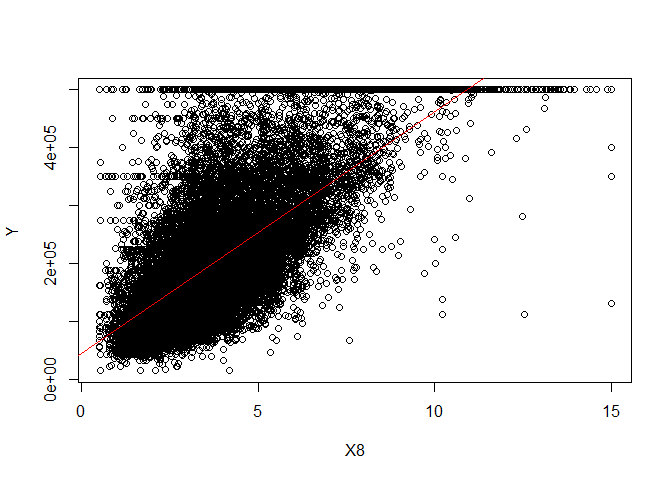

```r
plot(Y~X8, xtra)
abline(fit8, col="red")
```

```r
confint(fit8)
```

```
               2.5 %   97.5 %
(Intercept) 42492.64 47678.51
X8          41192.49 42395.21
```

## Modelos multivariables

Vamos a probar un modelo multivariable descendente. Con todas:

```r
fit0 <- lm(Y~., data=xtra)
summary(fit0)
```

```
Call:
lm(formula = Y ~ ., data = xtra)

Residuals:
    Min      1Q  Median      3Q     Max
-563013  -43592  -11327   30307  803996

Coefficients:
              Estimate Std. Error t value Pr(>|t|)
(Intercept) -3.594e+06  6.254e+04 -57.468  < 2e-16 ***
X1          -4.282e+04  7.130e+02 -60.061  < 2e-16 ***
X2          -4.258e+04  6.733e+02 -63.240  < 2e-16 ***
X3           1.156e+03  4.317e+01  26.787  < 2e-16 ***
X4          -8.182e+00  7.881e-01 -10.381  < 2e-16 ***
X5           1.134e+02  6.902e+00  16.432  < 2e-16 ***
X6          -3.854e+01  1.079e+00 -35.716  < 2e-16 ***
X7           4.831e+01  7.515e+00   6.429 1.32e-10 ***
X8           4.025e+04  3.351e+02 120.123  < 2e-16 ***
---
Signif. codes:  0 '***' 0.001 '**' 0.01 '*' 0.05 '.' 0.1 ' ' 1

Residual standard error: 69530 on 20631 degrees of freedom
Multiple R-squared:  0.6371,    Adjusted R-squared:  0.637
F-statistic:  4528 on 8 and 20631 DF,  p-value: < 2.2e-16
```

Todas nos sale con un p-value < 0.05, por lo que no nos indica que alguna sea irrelevante. Hay que notar que el R2 es mayor que ajustando X8 únicamente. Puesto que sigue siendo lineal (no se ha añadido mucha complejidad), podemos aceptar este modelo como mejor.

Pese a ello, vamos a comparar los R2 con eliminando una variable (a excepción de X8, que sabemos que es importante). (Todas tienen un p-value demasiado bajo como para dejarnos guiar por eso a la hora de eliminar, mejor probar con todas)

```r
fit1 <- lm(Y~.-X1, data=xtra)
fit2 <- lm(Y~.-X2, data=xtra)
fit3 <- lm(Y~.-X3, data=xtra)
fit4 <- lm(Y~.-X4, data=xtra)
fit5 <- lm(Y~.-X5, data=xtra)
fit6 <- lm(Y~.-X6, data=xtra)
fit7 <- lm(Y~.-X7, data=xtra)

summary(fit1)
summary(fit2)
summary(fit3)
summary(fit4)
summary(fit5)
summary(fit6)
summary(fit7)
```

```
Call:
lm(formula = Y ~ . - X1, data = xtra)

Residuals:
    Min      1Q  Median      3Q     Max
-618282  -47761  -12245   33997  775111

Coefficients:
              Estimate Std. Error t value Pr(>|t|)
(Intercept)  1.247e+05  9.551e+03   13.05   <2e-16 ***
X2          -4.637e+03  2.524e+02  -18.37   <2e-16 ***
X3           1.875e+03  4.495e+01   41.72   <2e-16 ***
X4          -1.695e+01  8.395e-01  -20.19   <2e-16 ***
X5           8.687e+01  7.465e+00   11.64   <2e-16 ***
X6          -3.878e+01  1.169e+00  -33.16   <2e-16 ***
X7           1.329e+02  8.000e+00   16.62   <2e-16 ***
X8           4.663e+04  3.444e+02  135.38   <2e-16 ***
---
Signif. codes:  0 '***' 0.001 '**' 0.01 '*' 0.05 '.' 0.1 ' ' 1

Residual standard error: 75360 on 20632 degrees of freedom
Multiple R-squared:  0.5737,    Adjusted R-squared:  0.5735
F-statistic:  3966 on 7 and 20632 DF,  p-value: < 2.2e-16


Call:
lm(formula = Y ~ . - X2, data = xtra)

Residuals:
    Min      1Q  Median      3Q     Max
-637335  -48054  -11660   34323  703265

Coefficients:
              Estimate Std. Error t value Pr(>|t|)
(Intercept) -1.076e+05  3.226e+04  -3.336  0.00085 ***
X1          -5.165e+02  2.695e+02  -1.917  0.05527 .
X3           1.873e+03  4.551e+01  41.150  < 2e-16 ***
X4          -1.980e+01  8.374e-01 -23.649  < 2e-16 ***
X5           1.021e+02  7.538e+00  13.542  < 2e-16 ***
X6          -3.517e+01  1.177e+00 -29.873  < 2e-16 ***
```

[output cut: 118 more lines]

```
              Estimate Std. Error t value Pr(>|t|)
(Intercept) -3.673e+06  6.139e+04  -59.83   <2e-16 ***
X1          -4.368e+04  7.010e+02  -62.31   <2e-16 ***
X2          -4.326e+04  6.654e+02  -65.02   <2e-16 ***
X3           1.165e+03  4.319e+01   26.99   <2e-16 ***
X4          -8.439e+00  7.879e-01  -10.71   <2e-16 ***
X5           1.497e+02  3.967e+00   37.74   <2e-16 ***
X6          -3.514e+01  9.416e-01  -37.32   <2e-16 ***
X8           4.042e+04  3.343e+02  120.91   <2e-16 ***
---
Signif. codes:  0 '***' 0.001 '**' 0.01 '*' 0.05 '.' 0.1 ' ' 1

Residual standard error: 69600 on 20632 degrees of freedom
Multiple R-squared:  0.6364,    Adjusted R-squared:  0.6363
F-statistic:  5158 on 7 and 20632 DF,  p-value: < 2.2e-16
```

```r
fit8 <- lm(Y~.-X8, data=xtra)
summary(fit8)
```

```
Call:
lm(formula = Y ~ . - X8, data = xtra)

Residuals:
    Min      1Q  Median      3Q     Max
-406050  -58598  -17156   40467 1231392

Coefficients:
              Estimate Std. Error t value Pr(>|t|)
(Intercept) -5.645e+06  7.843e+04 -71.976   <2e-16 ***
X1          -6.998e+04  8.815e+02 -79.389   <2e-16 ***
X2          -7.112e+04  8.212e+02 -86.604   <2e-16 ***
X3           4.877e+02  5.580e+01   8.739   <2e-16 ***
X4           4.823e+01  8.251e-01  58.445   <2e-16 ***
X5          -1.727e+02  8.445e+00 -20.446   <2e-16 ***
X6          -6.333e+01  1.381e+00 -45.874   <2e-16 ***
X7           1.206e+02  9.764e+00  12.353   <2e-16 ***
---
Signif. codes:  0 '***' 0.001 '**' 0.01 '*' 0.05 '.' 0.1 ' ' 1

Residual standard error: 90640 on 20632 degrees of freedom
Multiple R-squared:  0.3833,    Adjusted R-squared:  0.3831
F-statistic:  1832 on 7 and 20632 DF,  p-value: < 2.2e-16
```

Por obtener mayor simplicidad en el modelo, podríamos quitar X7 sin afectar mucho el R2. Podríamos seguir haciendo esto con X4 perdiendo solo un 0,2%

## Interacciones

```r
fit1 <- lm(Y~.-X7+X4*X8, data=xtra)
summary(fit1)
```

```
Call:
lm(formula = Y ~ . - X7 + X4 * X8, data = xtra)

Residuals:
    Min      1Q  Median      3Q     Max
-528635  -42914  -11399   29737  827777

Coefficients:
              Estimate Std. Error t value Pr(>|t|)
(Intercept) -3.549e+06  6.148e+04  -57.72   <2e-16 ***
X1          -4.232e+04  7.018e+02  -60.29   <2e-16 ***
X2          -4.167e+04  6.685e+02  -62.34   <2e-16 ***
X3           1.136e+03  4.296e+01   26.43   <2e-16 ***
X4          -2.537e+01  1.310e+00  -19.37   <2e-16 ***
X5           1.839e+02  4.476e+00   41.09   <2e-16 ***
X6          -3.422e+01  9.374e-01  -36.50   <2e-16 ***
X8           3.661e+04  4.076e+02   89.81   <2e-16 ***
X4:X8        2.150e+00  1.333e-01   16.13   <2e-16 ***
---
Signif. codes:  0 '***' 0.001 '**' 0.01 '*' 0.05 '.' 0.1 ' ' 1

Residual standard error: 69160 on 20631 degrees of freedom
Multiple R-squared:  0.6409,    Adjusted R-squared:  0.6408
F-statistic:  4603 on 8 and 20631 DF,  p-value: < 2.2e-16
```

Y vemos que la interacción aporta significativamente, tiene un p-value bajo (tambien el estadístico F)

Variables con correlación

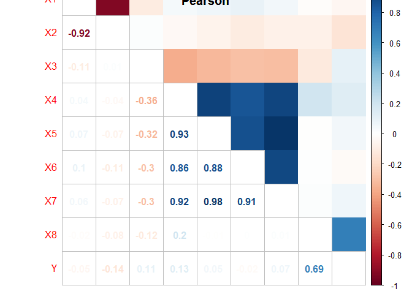

```r
corrplot.mixed(cor(xtra), tl.pos="lt", upper="color", title="Pearson")
```

Probamos a añadir X1 con X2

```r
fit1 <- lm(Y~.-X7+X4*X8+X1*X2, data=xtra)
summary(fit1)
```

```
Call:
lm(formula = Y ~ . - X7 + X4 * X8 + X1 * X2, data = xtra)

Residuals:
    Min      1Q  Median      3Q     Max
-529130  -42873  -11400   29835  833827

Coefficients:
              Estimate Std. Error t value Pr(>|t|)
(Intercept) -6.066e+06  7.339e+05  -8.265  < 2e-16 ***
X1          -6.327e+04  6.131e+03 -10.321  < 2e-16 ***
X2           2.909e+04  2.058e+04   1.414  0.15738
X3           1.131e+03  4.297e+01  26.316  < 2e-16 ***
X4          -2.518e+01  1.310e+00 -19.223  < 2e-16 ***
X5           1.838e+02  4.475e+00  41.071  < 2e-16 ***
X6          -3.445e+01  9.395e-01 -36.663  < 2e-16 ***
X8           3.657e+04  4.077e+02  89.707  < 2e-16 ***
X4:X8        2.140e+00  1.333e-01  16.055  < 2e-16 ***
X1:X2        5.887e+02  1.711e+02   3.441  0.00058 ***
---
Signif. codes:  0 '***' 0.001 '**' 0.01 '*' 0.05 '.' 0.1 ' ' 1

Residual standard error: 69150 on 20630 degrees of freedom
Multiple R-squared:  0.6411,    Adjusted R-squared:  0.641
F-statistic:  4095 on 9 and 20630 DF,  p-value: < 2.2e-16
```

Nos dice de quitar X2 pero al ser un término de jerarquía no podemos. No aporta una gran mejora respecto al modelo aditivo previo.

```r
fit1 <- lm(Y~.+X4*X8+X5*X7, data=xtra)
summary(fit1)
```

```
Call:
lm(formula = Y ~ . + X4 * X8 + X5 * X7, data = xtra)

Residuals:
    Min      1Q  Median      3Q     Max
-521846  -42939  -11571   29403  936309

Coefficients:
              Estimate Std. Error t value Pr(>|t|)
(Intercept) -3.475e+06  6.249e+04 -55.613  < 2e-16 ***
X1          -4.142e+04  7.127e+02 -58.115  < 2e-16 ***
X2          -4.090e+04  6.756e+02 -60.542  < 2e-16 ***
X3           1.167e+03  4.323e+01  26.988  < 2e-16 ***
X4          -2.442e+01  1.313e+00 -18.598  < 2e-16 ***
X5           1.588e+02  7.349e+00  21.608  < 2e-16 ***
X6          -3.639e+01  1.079e+00 -33.715  < 2e-16 ***
X7           4.546e+01  7.528e+00   6.038 1.58e-09 ***
X8           3.647e+04  4.072e+02  89.562  < 2e-16 ***
X4:X8        2.133e+00  1.335e-01  15.972  < 2e-16 ***
X5:X7       -6.249e-03  8.816e-04  -7.089 1.39e-12 ***
---
Signif. codes:  0 '***' 0.001 '**' 0.01 '*' 0.05 '.' 0.1 ' ' 1

Residual standard error: 69040 on 20629 degrees of freedom
Multiple R-squared:  0.6423,    Adjusted R-squared:  0.6421
F-statistic:  3704 on 10 and 20629 DF,  p-value: < 2.2e-16
```

Añadimos interacción X5-X7 y el modelo mejora, y no necesitamos quitar ninguna variable

## No linealidad

```r
fit1 <- lm(Y~.+X4*X8+X5*X7+I(X1^2), data=xtra)
summary(fit1)
```

```
Call:
lm(formula = Y ~ . + X4 * X8 + X5 * X7 + I(X1^2), data = xtra)

Residuals:
    Min      1Q  Median      3Q     Max
-522386  -43056  -11688   29709  943626

Coefficients:
              Estimate Std. Error t value Pr(>|t|)
(Intercept) -1.409e+07  2.280e+06  -6.182 6.45e-10 ***
X1          -2.186e+05  3.803e+04  -5.747 9.19e-09 ***
X2          -4.098e+04  6.755e+02 -60.674  < 2e-16 ***
X3           1.162e+03  4.322e+01  26.875  < 2e-16 ***
X4          -2.401e+01  1.315e+00 -18.251  < 2e-16 ***
X5           1.602e+02  7.352e+00  21.793  < 2e-16 ***
X6          -3.669e+01  1.081e+00 -33.948  < 2e-16 ***
X7           4.329e+01  7.538e+00   5.742 9.47e-09 ***
X8           3.646e+04  4.070e+02  89.569  < 2e-16 ***
I(X1^2)     -7.387e+02  1.585e+02  -4.659 3.19e-06 ***
X4:X8        2.105e+00  1.336e-01  15.755  < 2e-16 ***
X5:X7       -6.269e-03  8.811e-04  -7.115 1.16e-12 ***
---
Signif. codes:  0 '***' 0.001 '**' 0.01 '*' 0.05 '.' 0.1 ' ' 1

Residual standard error: 69000 on 20628 degrees of freedom
Multiple R-squared:  0.6426,    Adjusted R-squared:  0.6424
F-statistic:  3372 on 11 and 20628 DF,  p-value: < 2.2e-16
```

El modelo es válido, pero la mejora es ínfima y añade peor interpretabilidad, no merece la pena.

```r
fit1 <- lm(Y~.+X4*X8+X5*X7+I(log(X8)), data=xtra)
summary(fit1)
```

```
Call:
lm(formula = Y ~ . + X4 * X8 + X5 * X7 + I(log(X8)), data = xtra)

Residuals:
    Min      1Q  Median      3Q     Max
-508787  -43099  -11525   29647  935003

Coefficients:
              Estimate Std. Error t value Pr(>|t|)
(Intercept) -3.447e+06  6.302e+04 -54.692  < 2e-16 ***
X1          -4.103e+04  7.214e+02 -56.875  < 2e-16 ***
X2          -4.049e+04  6.861e+02 -59.008  < 2e-16 ***
X3           1.176e+03  4.330e+01  27.153  < 2e-16 ***
X4          -2.609e+01  1.401e+00 -18.625  < 2e-16 ***
X5           1.643e+02  7.524e+00  21.841  < 2e-16 ***
X6          -3.595e+01  1.087e+00 -33.086  < 2e-16 ***
X7           4.262e+01  7.572e+00   5.629 1.84e-08 ***
X8           3.379e+04  8.861e+02  38.130  < 2e-16 ***
I(log(X8))   1.097e+04  3.217e+03   3.411  0.00065 ***
X4:X8        2.290e+00  1.412e-01  16.214  < 2e-16 ***
X5:X7       -6.081e-03  8.827e-04  -6.889 5.79e-12 ***
---
Signif. codes:  0 '***' 0.001 '**' 0.01 '*' 0.05 '.' 0.1 ' ' 1

Residual standard error: 69020 on 20628 degrees of freedom
Multiple R-squared:  0.6425,    Adjusted R-squared:  0.6423
F-statistic:  3370 on 11 and 20628 DF,  p-value: < 2.2e-16
```

Lo mismo que en el caso anterior

## KNN

```r
fitknn1 <- kknn(Y ~ ., xtra, xtra) # Por defecto k = 7, distance = 2, kernel = "optimal" y scale=TRUE
summary(fitknn1$fitted.values)
```

```
   Min. 1st Qu.  Median    Mean 3rd Qu.    Max.
  45538  130079  185936  205742  261058  500001
```

RMSE

```r
yprime <- fitknn1$fitted.values

sqrt(sum((xtra$Y-yprime)^2)/length(yprime)) #RMSE
```

```
[1] 39131.14
```

Modelo aditivo anterior

```r
fitknn2 <- kknn(Y~.+X4*X8+X5*X7, xtra, xtra)

yprime <- fitknn2$fitted.values
sqrt(sum((xtra$Y-yprime)^2)/length(yprime)) #RMSE
```

```
[1] 38300.29
```

Bajamos algo, pero poco.

## Cross-validation

```r
#------------- 5-fold cross-validation LM todas las variables
nombre <- "data/california"

run_lm_fold <- function(i, x, tt = "test") {
    file <- paste(x, "-5-", i, "tra.dat", sep="")
    x_tra <- read.csv(file, comment.char="@", header=FALSE)
    file <- paste(x, "-5-", i, "tst.dat", sep="")
    x_tst <- read.csv(file, comment.char="@", header=FALSE)
    In <- length(names(x_tra)) - 1

    names(x_tra)[1:In] <- paste ("X", 1:In, sep="")
    names(x_tra)[In+1] <- "Y"
    names(x_tst)[1:In] <- paste ("X", 1:In, sep="")
    names(x_tst)[In+1] <- "Y"

    if (tt == "train") {
        test <- x_tra
    }
    else {
        test <- x_tst
    }

    fitMulti=lm(Y~.,x_tra)
    yprime=predict(fitMulti,test)
    sum(abs(test$Y-yprime)^2)/length(yprime) ## RMSE
}

lmMSEtrain<-mean(sapply(1:5,run_lm_fold,nombre,"train"))
lmMSEtest<-mean(sapply(1:5,run_lm_fold,nombre,"test"))
```

```r
#------------- 5-fold cross-validation KNN todas las variables
nombre <- "data/california"

run_knn_fold <- function(i, x, tt = "test") {
    file <- paste(x, "-5-", i, "tra.dat", sep="")
    x_tra <- read.csv(file, comment.char="@", header=FALSE)
    file <- paste(x, "-5-", i, "tst.dat", sep="")
    x_tst <- read.csv(file, comment.char="@", header=FALSE)
    In <- length(names(x_tra)) - 1

    names(x_tra)[1:In] <- paste ("X", 1:In, sep="")
    names(x_tra)[In+1] <- "Y"
    names(x_tst)[1:In] <- paste ("X", 1:In, sep="")
    names(x_tst)[In+1] <- "Y"

    if (tt == "train") {
        test <- x_tra
    }
    else {
        test <- x_tst
    }

    fitMulti=kknn(Y~.,x_tra,test)
    yprime=fitMulti$fitted.values
    sum(abs(test$Y-yprime)^2)/length(yprime) ##RMSE
}
knnMSEtrain<-mean(sapply(1:5,run_knn_fold,nombre,"train"))
knnMSEtest<-mean(sapply(1:5,run_knn_fold,nombre,"test"))
```

Resultados

```r
lmMSEtest
knnMSEtest
```

```
[1] 4848069879
[1] 3847242396
```

KNN supera, y por mucho

En training

```r
lmMSEtrain
knnMSEtrain
```

```
[1] 4830423550
[1] 1562164927
```

## Comparativas entre algoritmos

```r
#------------------- COMPARATIVAS GENERALES ENTRE ALGORITMOS

# Leemos la tabla con los errores medios de test
resultados <- read.csv("data/regr_test_alumnos.csv")
tablatst <- cbind(resultados[,2:dim(resultados)[2]])
colnames(tablatst) <- names(resultados)[2:dim(resultados)[2]]
rownames(tablatst) <- resultados[,1]

# Leemos la tabla con los errores medios de entrenamiento
resultados <- read.csv("data/regr_train_alumnos.csv")
tablatra <- cbind(resultados[,2:dim(resultados)[2]])
colnames(tablatra) <- names(resultados)[2:dim(resultados)[2]]
rownames(tablatra) <- resultados[,1]

# TABLA NORMALIZADA - lm (other) vs knn (ref) para WILCOXON
# + 0.1 porque wilcox R falla para valores == 0 en la tabla

difs <- (tablatst[,1] - tablatst[,2]) / tablatst[,1]
wilc_1_2 <- cbind(ifelse (difs<0, abs(difs)+0.1, 0+0.1), ifelse (difs>0,    abs(difs)+0.1, 0+0.1))
colnames(wilc_1_2) <- c(colnames(tablatst)[1], colnames(tablatst)[2])
head(wilc_1_2)
```

```
     out_test_lm out_test_kknn
[1,]   0.1909091     0.1000000
[2,]   0.1000000     1.0294118
[3,]   0.1000000     0.4339071
[4,]   0.1000000     0.3885965
[5,]   0.1548506     0.1000000
[6,]   0.1000000     0.3061057
```

```r
# Aplicación del test de WILCOXON
LMvsKNNtst <- wilcox.test(wilc_1_2[,1], wilc_1_2[,2], alternative = "two.sided", paired=TRUE)
Rmas <- LMvsKNNtst$statistic

pvalue <- LMvsKNNtst$p.value

LMvsKNNtst <- wilcox.test(wilc_1_2[,2], wilc_1_2[,1], alternative = "two.sided", paired=TRUE)
Rmenos <- LMvsKNNtst$statistic

Rmas
Rmenos
pvalue
```

```
 V
78
 V
93
[1] 0.7660294
```

Nos dice que gana KNN pero el p-value no es suficiente para tomar esta afirmación como cierta.

```r
# Aplicación del test de Friedman
test_friedman <- friedman.test(as.matrix(tablatst))
test_friedman
```

```
    Friedman rank sum test

data:  as.matrix(tablatst)
Friedman chi-squared = 8.4444, df = 2, p-value = 0.01467
```

El p-value es <0.05 por lo que podemos concluir que al menos hay un par de algoritmos de calidad diferente.

```r
# Aplicación del test post-hoc de HOLM
tam <- dim(tablatst)
groups <- rep(1:tam[2], each=tam[1])
pairwise.wilcox.test(as.matrix(tablatst), groups, p.adjust = "holm", paired = TRUE)
```

```
    Pairwise comparisons using Wilcoxon signed rank exact test

data:  as.matrix(tablatst) and groups

  1     2
2 0.580 -
3 0.081 0.108

P value adjustment method: holm
```